# Prosper Loan Exploration by Benjamin Lee

```
##  [1] "ListingKey"
##  [2] "ListingNumber"
##  [3] "ListingCreationDate"
##  [4] "CreditGrade"
##  [5] "Term"
##  [6] "LoanStatus"
##  [7] "ClosedDate"
##  [8] "BorrowerAPR"
##  [9] "BorrowerRate"
## [10] "LenderYield"
## [11] "EstimatedEffectiveYield"
## [12] "EstimatedLoss"
## [13] "EstimatedReturn"
## [14] "ProsperRating_numeric"
## [15] "ProsperRating_Alpha"
```

[output cut: 68 more lines]

```
## 'data.frame':    113937 obs. of  83 variables:
##  $ ListingKey                         : Factor w/ 113066 levels "00003546482094282EF90E5",..: 7180 7193 6647 6669 6686 6689 6699 6706 6687 6687 ...
##  $ ListingNumber                      : int  193129 1209647 81716 658116 909464 1074836 750899 768193 1023355 1023355 ...
##  $ ListingCreationDate                : Factor w/ 113064 levels "2005-11-09 20:44:28.847000000",..: 14184 111894 6429 64760 85967 100310 72556 74019 97834 97834 ...
##  $ CreditGrade                        : Factor w/ 9 levels "","A","AA","B",..: 5 1 8 1 1 1 1 1 1 1 ...
##  $ Term                               : Factor w/ 3 levels "12","36","60": 2 2 2 2 2 3 2 2 2 2 ...
##  $ LoanStatus                         : Factor w/ 12 levels "Cancelled","Chargedoff",..: 3 4 3 4 4 4 4 4 4 4 ...
##  $ ClosedDate                         : Factor w/ 2803 levels "","2005-11-25 00:00:00",..: 1138 1 1263 1 1 1 1 1 1 1 ...
##  $ BorrowerAPR                        : num  0.165 0.12 0.283 0.125 0.246 ...
##  $ BorrowerRate                       : num  0.158 0.092 0.275 0.0974 0.2085 ...
##  $ LenderYield                        : num  0.138 0.082 0.24 0.0874 0.1985 ...
##  $ EstimatedEffectiveYield            : num  NA 0.0796 NA 0.0849 0.1832 ...
##  $ EstimatedLoss                      : num  NA 0.0249 NA 0.0249 0.0925 ...
##  $ EstimatedReturn                    : num  NA 0.0547 NA 0.06 0.0907 ...
##  $ ProsperRating_numeric              : Factor w/ 7 levels "1","2","3","4",..: NA 6 NA 6 3 5 2 4 7 7 ...
```

[output cut: 69 more lines]

```
##                    ListingKey     ListingNumber
##  17A93590655669644DB4C06:     6   Min.   :      4
##  349D3587495831350F0F648:     4   1st Qu.: 400919
##  47C1359638497431975670B:     4   Median : 600554
##  8474358854651984137201C:     4   Mean   : 627886
##  DE8535960513435199406CE:     4   3rd Qu.: 892634
##  04C13599434217079754AEE:     3   Max.   :1255725
##  (Other)                :113912
##                     ListingCreationDate  CreditGrade    Term
##  2013-10-02 17:20:16.550000000:     6          :84984   12: 1614
##  2013-08-28 20:31:41.107000000:     4   C      : 5649   36:87778
##  2013-09-08 09:27:44.853000000:     4   D      : 5153   60:24545
##  2013-12-06 05:43:13.830000000:     4   B      : 4389
##  2013-12-06 11:44:58.283000000:     4   AA     : 3509
##  2013-08-21 07:25:22.360000000:     3   HR     : 3508
##  (Other)                      :113912   (Other): 6745
##                  LoanStatus                  ClosedDate
##  Current              :56576                      :58848
##  Completed            :38074   2014-03-04 00:00:00:  105
##  Chargedoff           :11992   2014-02-19 00:00:00:  100
##  Defaulted            : 5018   2014-02-11 00:00:00:   92
##  Past Due (1-15 days) :  806   2012-10-30 00:00:00:   81
##  Past Due (31-60 days):  363   2013-02-26 00:00:00:   78
##  (Other)              : 1108   (Other)            :54633
##   BorrowerAPR       BorrowerRate     LenderYield
##  Min.   :0.00653   Min.   :0.0000   Min.   :-0.0100
##  1st Qu.:0.15629   1st Qu.:0.1340   1st Qu.: 0.1242
##  Median :0.20976   Median :0.1840   Median : 0.1730
##  Mean   :0.21883   Mean   :0.1928   Mean   : 0.1827
##  3rd Qu.:0.28381   3rd Qu.:0.2500   3rd Qu.: 0.2400
##  Max.   :0.51229   Max.   :0.4975   Max.   : 0.4925
##  NA's   :25
##  EstimatedEffectiveYield EstimatedLoss   EstimatedReturn
##  Min.   :-0.183          Min.   :0.005   Min.   :-0.183
##  1st Qu.: 0.116          1st Qu.:0.042   1st Qu.: 0.074
##  Median : 0.162          Median :0.072   Median : 0.092
##  Mean   : 0.169          Mean   :0.080   Mean   : 0.096
##  3rd Qu.: 0.224          3rd Qu.:0.112   3rd Qu.: 0.117
##  Max.   : 0.320          Max.   :0.366   Max.   : 0.284
##  NA's   :29084           NA's   :29084   NA's   :29084
```

[output cut: 201 more lines]

```
##  Min.   : 0.00000           Min.   :    0.00            Min.   :   1.00
##  1st Qu.: 0.00000           1st Qu.:    0.00            1st Qu.:   2.00
##  Median : 0.00000           Median :    0.00            Median :  44.00
##  Mean   : 0.02346           Mean   :   16.55            Mean   :  80.48
##  3rd Qu.: 0.00000           3rd Qu.:    0.00            3rd Qu.: 115.00
##  Max.   :33.00000           Max.   :25000.00            Max.   :1189.00
##
##     occupationCategory     empidx
##  Professional:30221    Min.   :-718.0
##  Other       :28617    1st Qu.:  40.0
##  Assistant   :11245    Median : 129.0
##  Sales       : 9568    Mean   : 193.6
##  SkilledLabor: 9513    3rd Qu.: 282.0
##  School      : 5603    Max.   :1869.0
##  (Other)     :19170
```

# Univariate Plots Section

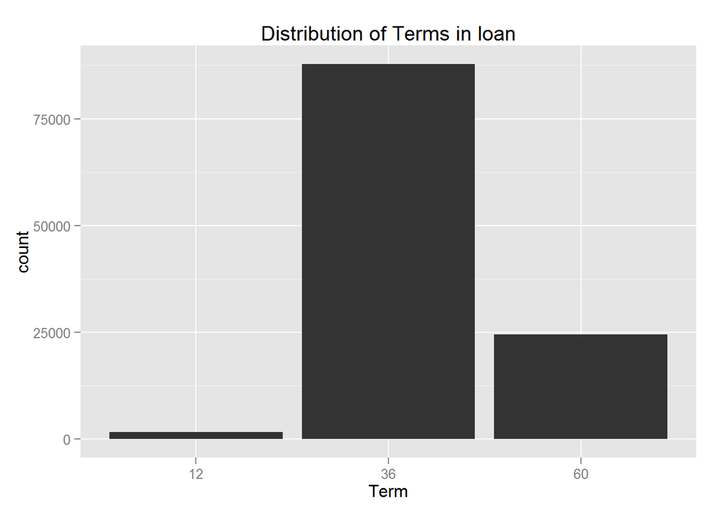

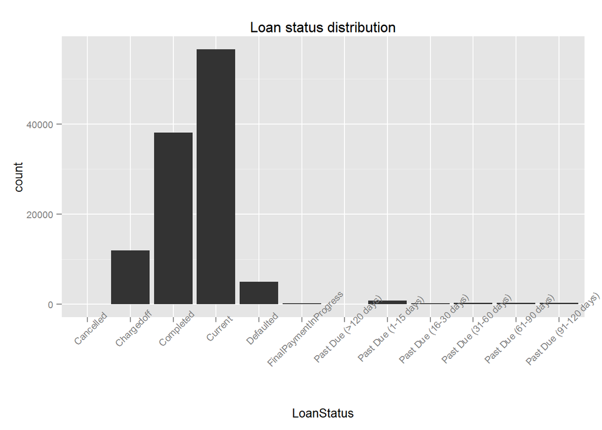

```
## stat_bin: binwidth defaulted to range/30. Use 'binwidth = x' to adjust this.
```

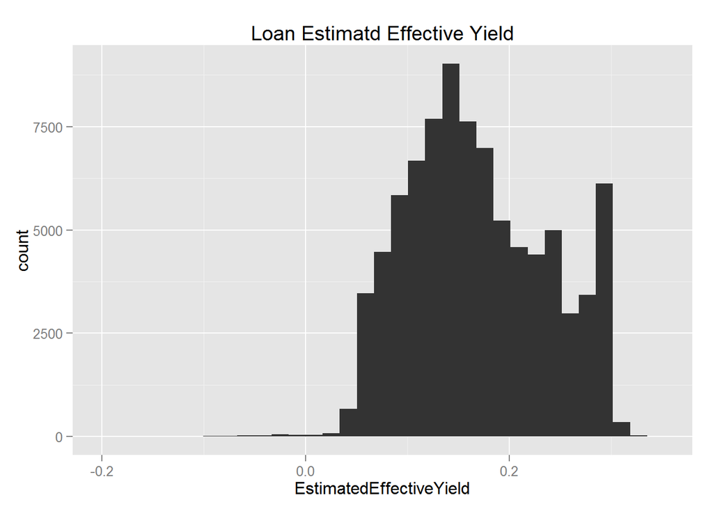

```
## stat_bin: binwidth defaulted to range/30. Use 'binwidth = x' to adjust this.
```

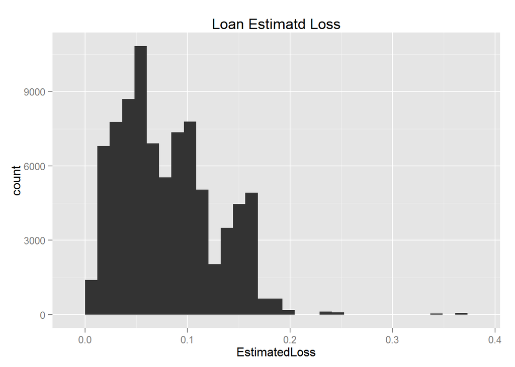

```
## stat_bin: binwidth defaulted to range/30. Use 'binwidth = x' to adjust this.
```

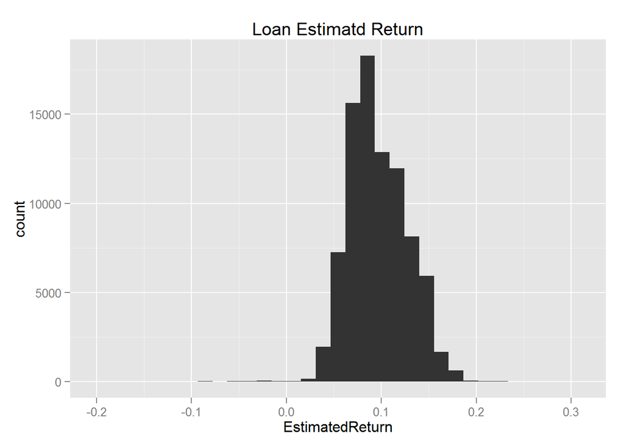

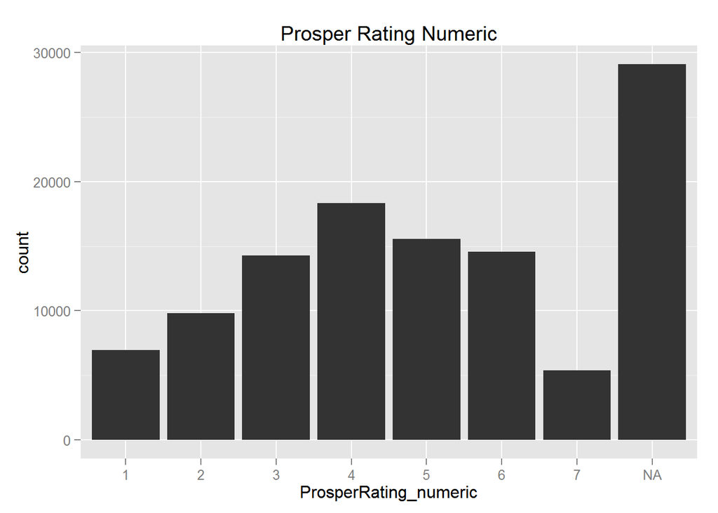

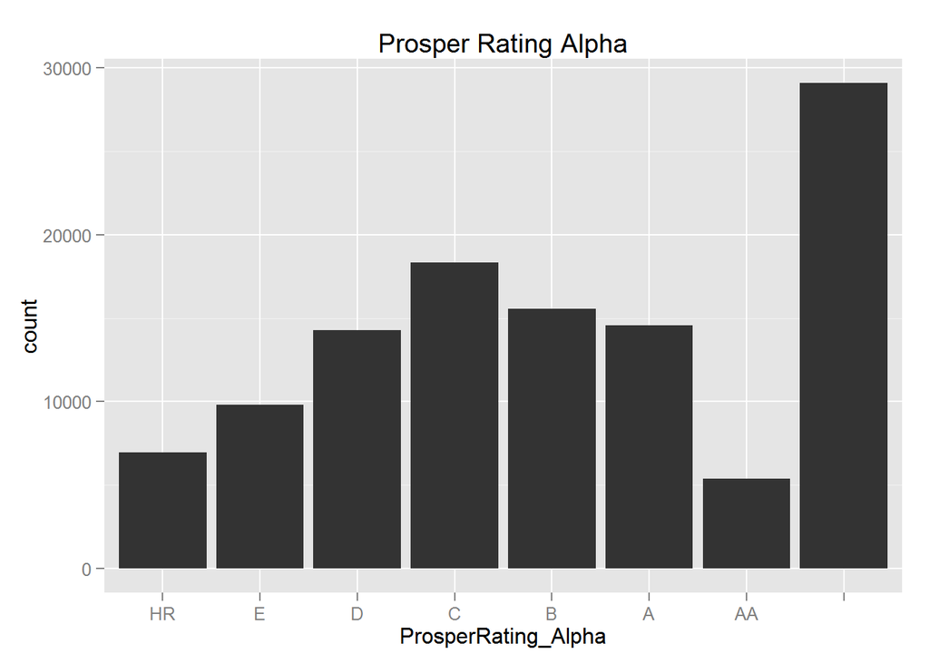

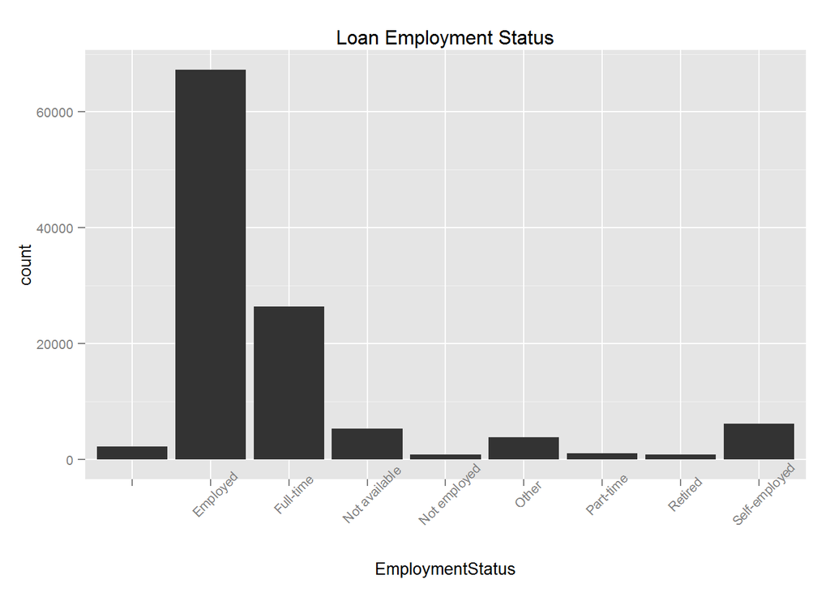

```
## stat_bin: binwidth defaulted to range/30. Use 'binwidth = x' to adjust this.
```

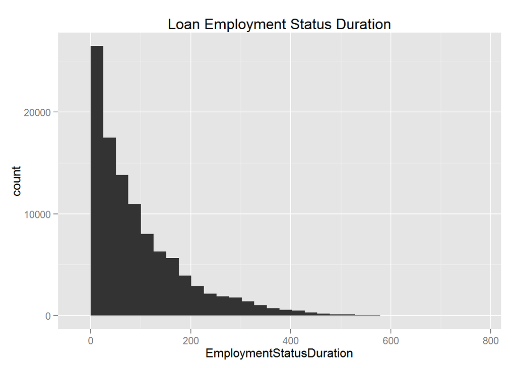

```
## stat_bin: binwidth defaulted to range/30. Use 'binwidth = x' to adjust this.
```

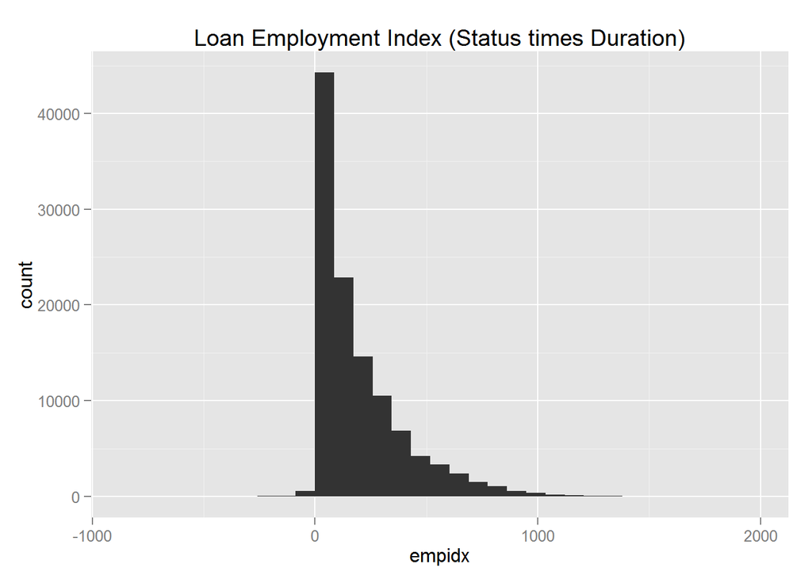

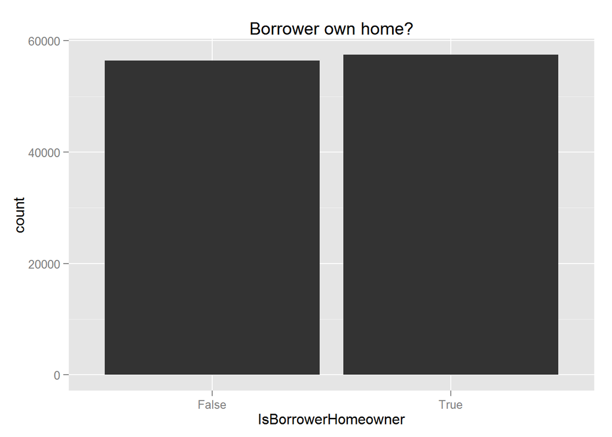

```
## stat_bin: binwidth defaulted to range/30. Use 'binwidth = x' to adjust this.
```

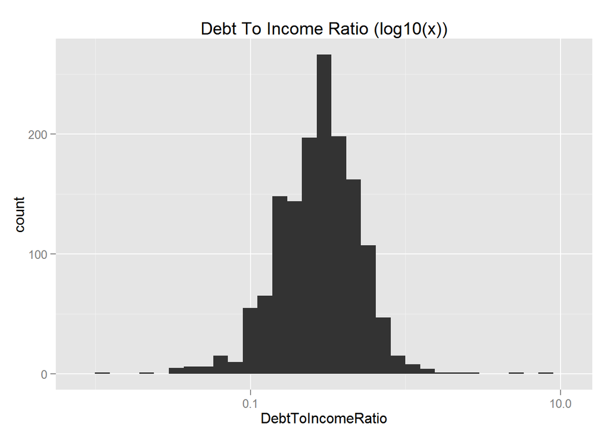

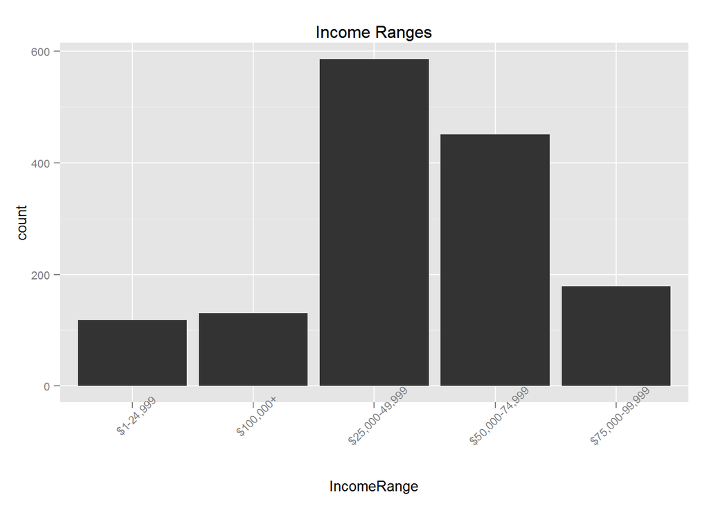

```
## stat_bin: binwidth defaulted to range/30. Use 'binwidth = x' to adjust this.
```

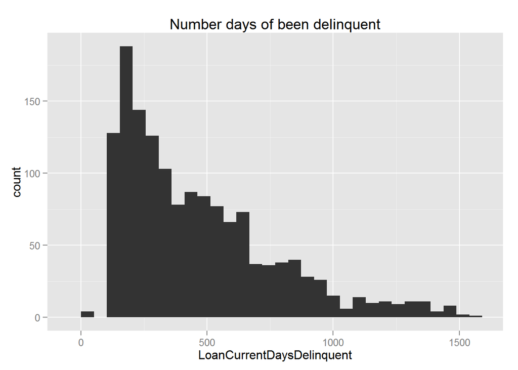

```
## stat_bin: binwidth defaulted to range/30. Use 'binwidth = x' to adjust this.
```

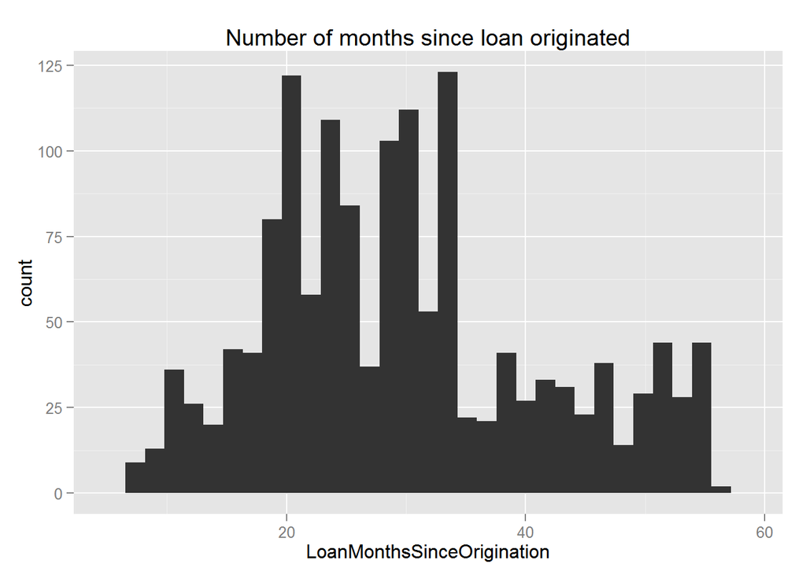

```
## stat_bin: binwidth defaulted to range/30. Use 'binwidth = x' to adjust this.
```

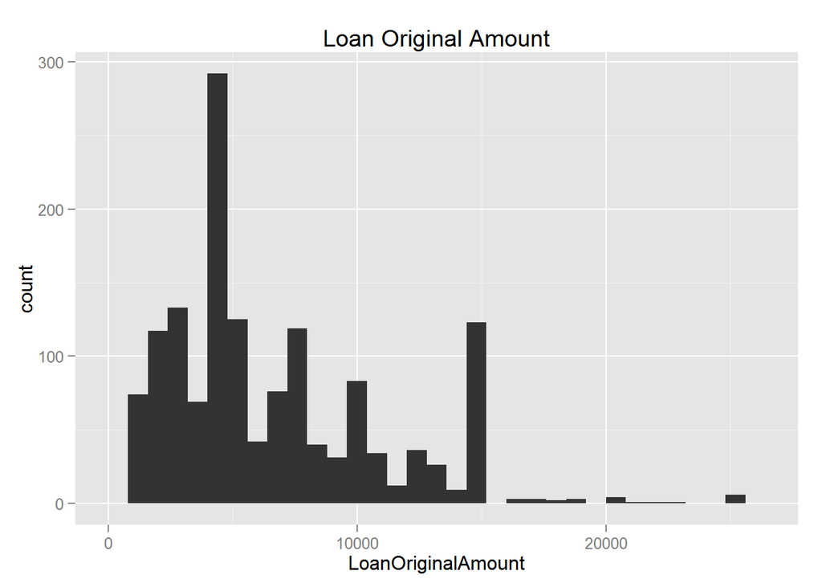

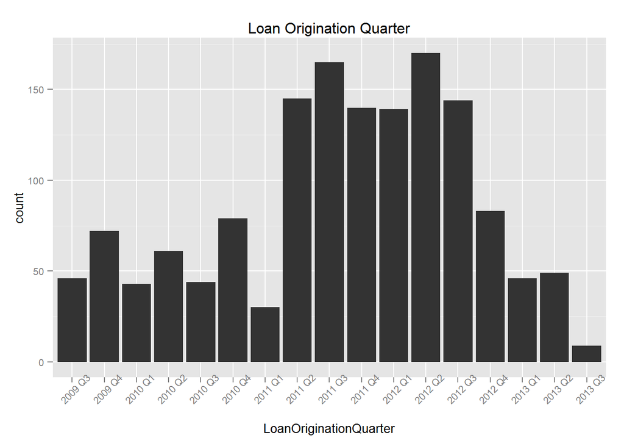

```
## stat_bin: binwidth defaulted to range/30. Use 'binwidth = x' to adjust this.
```

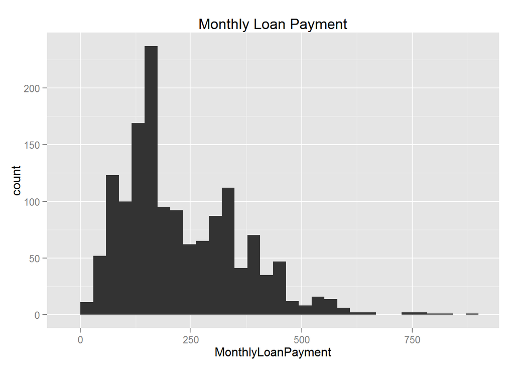

```
## stat_bin: binwidth defaulted to range/30. Use 'binwidth = x' to adjust this.
```

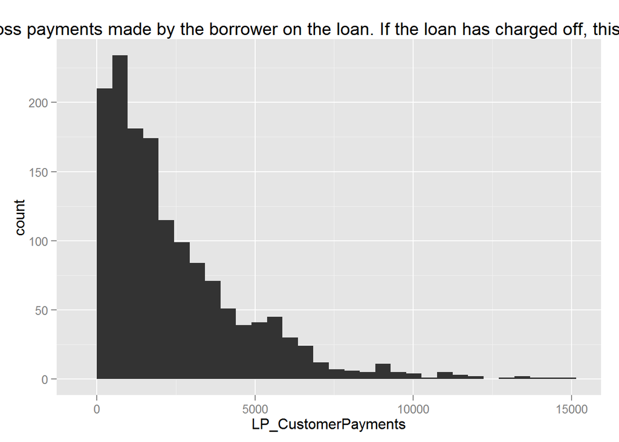

```
## stat_bin: binwidth defaulted to range/30. Use 'binwidth = x' to adjust this.
```

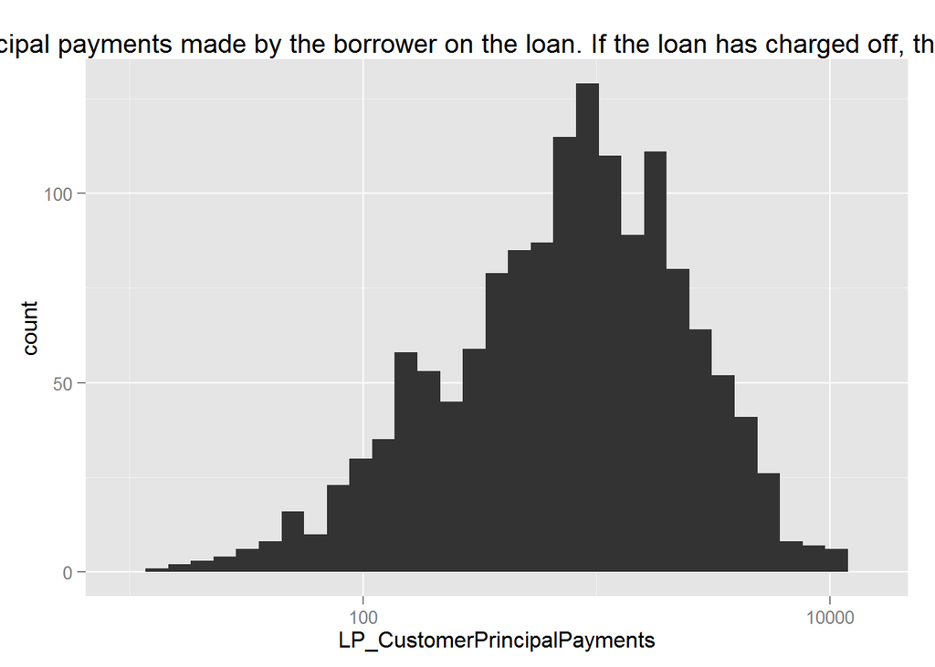

```
## stat_bin: binwidth defaulted to range/30. Use 'binwidth = x' to adjust this.
```

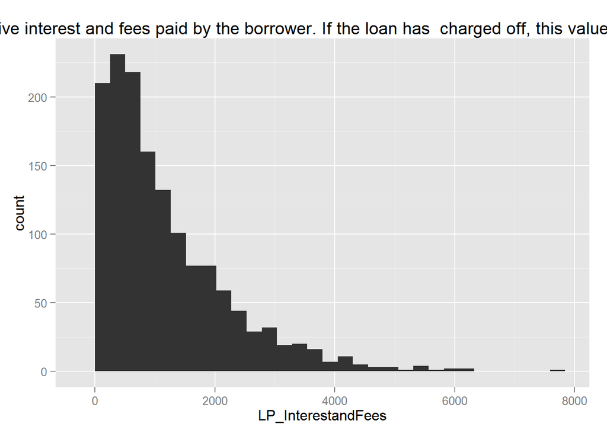

```
## stat_bin: binwidth defaulted to range/30. Use 'binwidth = x' to adjust this.
```

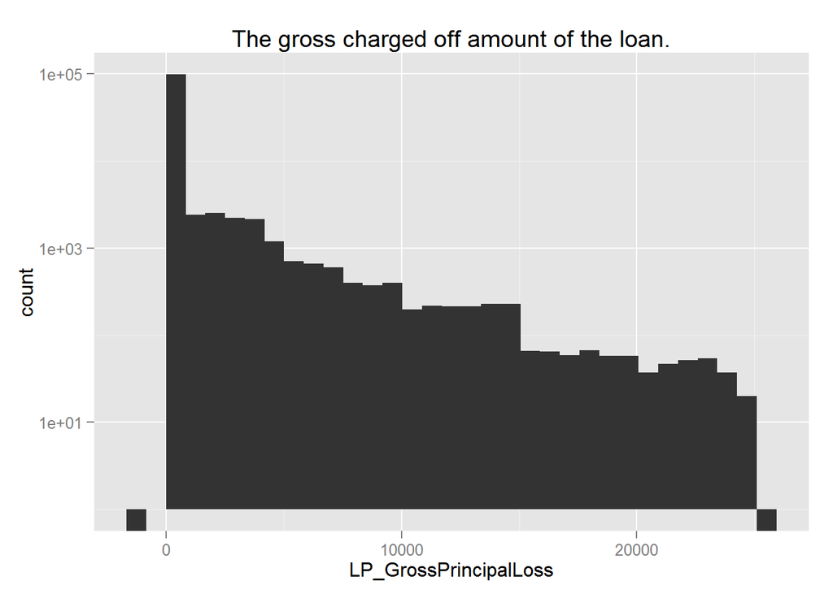

```
## stat_bin: binwidth defaulted to range/30. Use 'binwidth = x' to adjust this.
```

[figure not shown]

# Univariate Analysis

### What is the structure of your dataset?

Investment seems to be a difficult process. As much of analysis efforts spent, it shows data seems not following a specific pattern. Unlike any natural products, financial has a very distinct human factor.  
### What is/are the main feature(s) of interest in your dataset?  
I set out to find out how does the investment return reflected in the prosper loan data. And what is the time elapsed impact to profitability in prosper loan program.  
### What other features in the dataset do you think will help support your investigation into your feature(s) of interest?  
In study relationship of all spectrum of this data:  
. Employment status  
. Delinquency, public record present and past  
. Job category  
. Loan history  
. Credit rating of various sources (credit scores, ratings, bank cards, revolving credits, tradelines)  
. Purpose of loan (ListingCategory)  
. Date of loan as may be related to economical cycles  
. Financial situation (Income, home ownership, DebtToIncomeRatio)  
. Cash committed (In turns of fees, interests, and principles). This can be related to age of existing loan.

### Did you create any new variables from existing variables in the dataset?

Additional field “occupationCategory” has been added to assist study into Occupancy field:  
Category Civil:  
. Civil Service  
. Social Worker  
. Clergy  
. ReligiousClergy  
. Religious  
Category Medical:  
. Dentist  
. Doctor  
. Medical Technician  
. Nurse’s Aide  
. Nurse (LPN)  
. Nurse (RN)  
Category Professional:  
. Judge  
. Accountant/CPA  
. Chemist  
. Computer Programmer  
. Engineer - Chemical  
. Engineer - Electrical  
. Engineer - Mechanical  
. Pilot - Private/Commercial  
. Pharmacist  
. Professional  
. Psychologist  
. Analyst  
. Architect  
. Attorney  
. Biologist  
. Scientist  
Category Sales:  
. Car Dealer  
. Sales - Commission  
. Sales - Retail  
. Realtor  
. Retail Management  
Category Exec:  
. Executive  
. Investor  
Category Assistant:  
. Food Service  
. Food Service Management  
. Administrative Assistant  
. Clerical  
. Laborer  
. Waiter/Waitress  
Category SkilledLabor:  
. Flight Attendant  
. Skilled Labor  
. Fireman  
. Police Officer/Correction Officer  
. Postal Service  
. Bus Driver  
. Construction  
. Truck Driver  
. Landscaping  
Category Military:  
. Military Enlisted  
. Military Officer  
Category Other:  
. Other  
Category School:  
. Principal  
. Professor  
. Student - College Freshman  
. Student - College Graduate Student  
. Student - College Junior  
. Student - College Senior  
. Student - College Sophomore  
. Student - Community College  
. Student - Technical School  
. Teacher  
. Teacher’s Aide  
Category Tradesman:  
. Tradesman - Carpenter  
. Tradesman - Electrician  
. Tradesman - Mechanic  
. Tradesman - Plumber  
Category Homemaker:  
. Homemaker

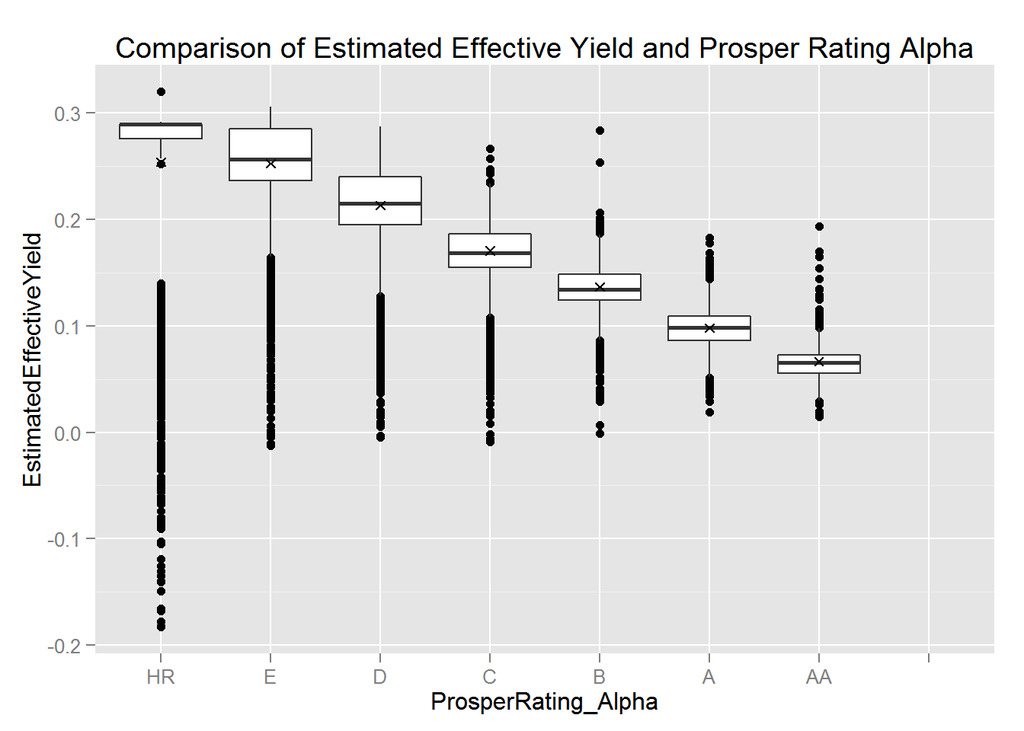

This plot shows a tightening of rates with higer grade of loan. Outliers below 0 are most likely from defaulted or charged loans.

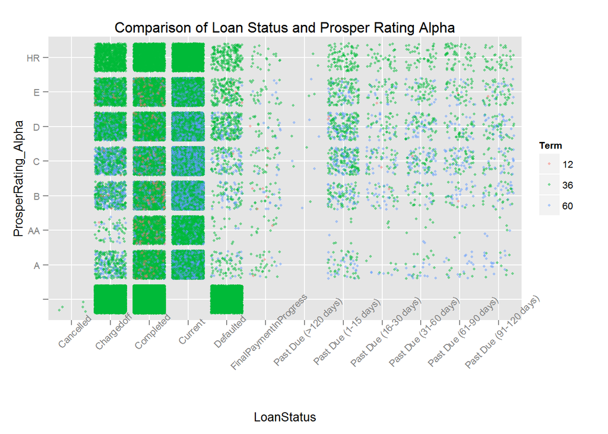

This plot does not show specific rating and loanStatus relationship.

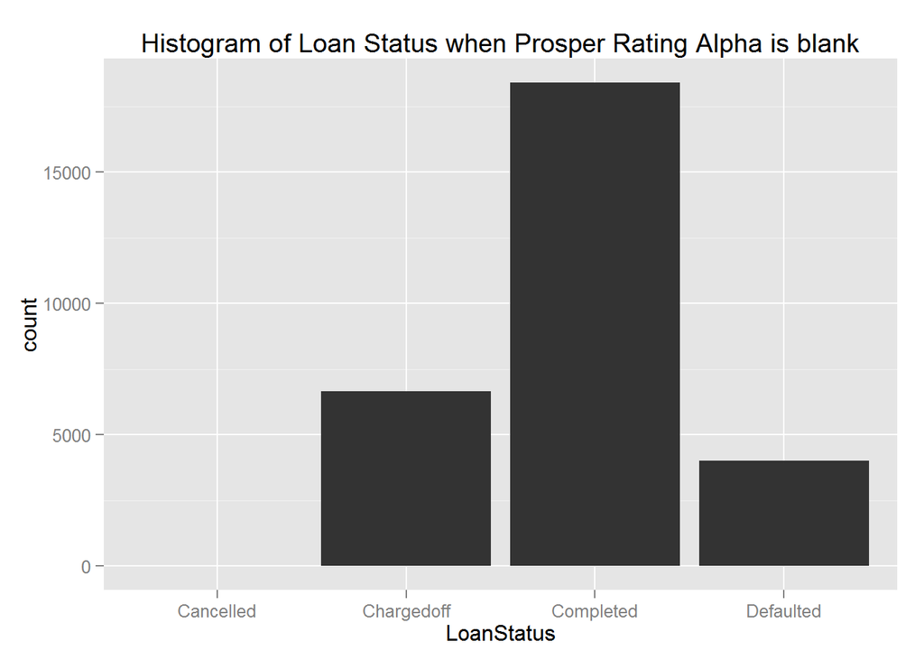

For prosperRating equal to empty, there’s a large proportion of chargeoff and defaulted loan.

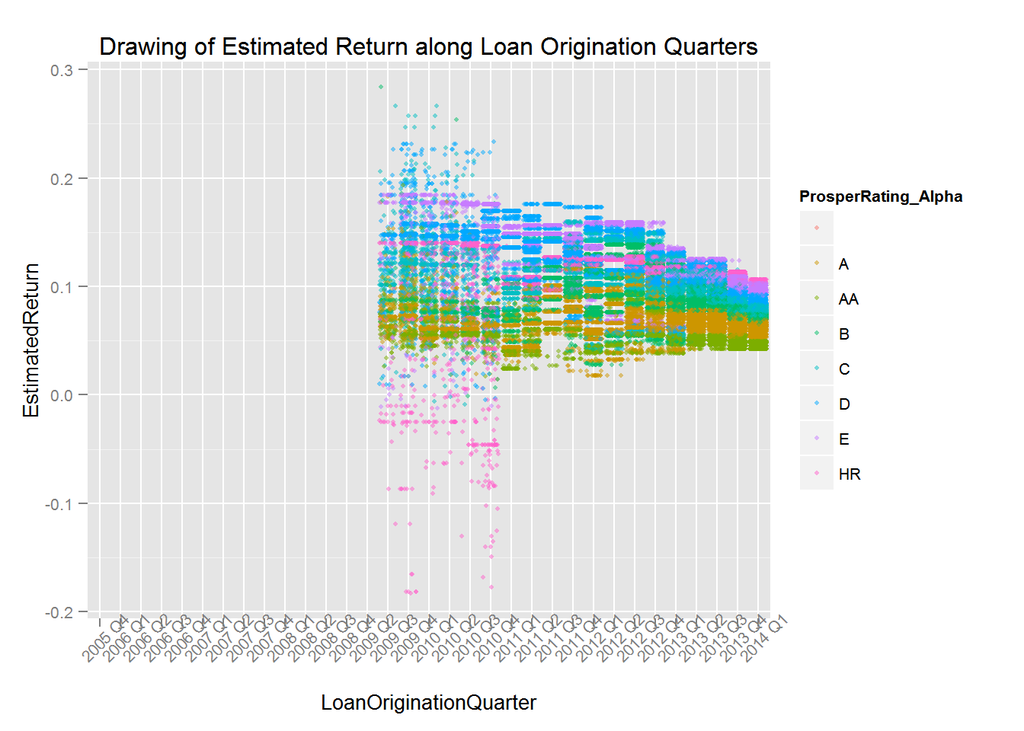

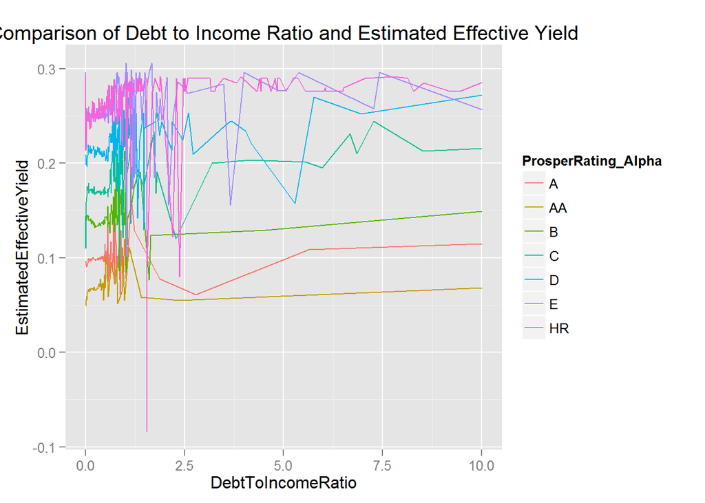

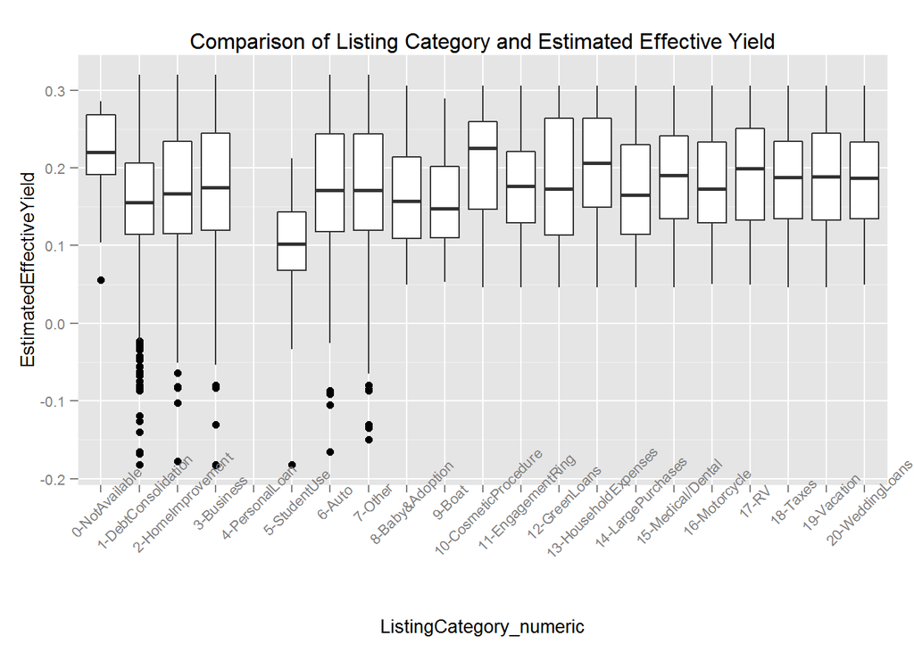

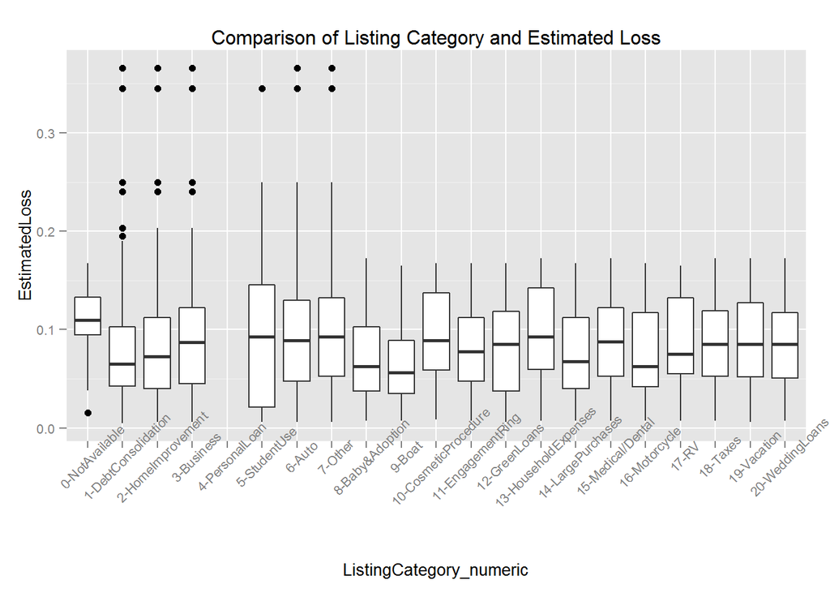

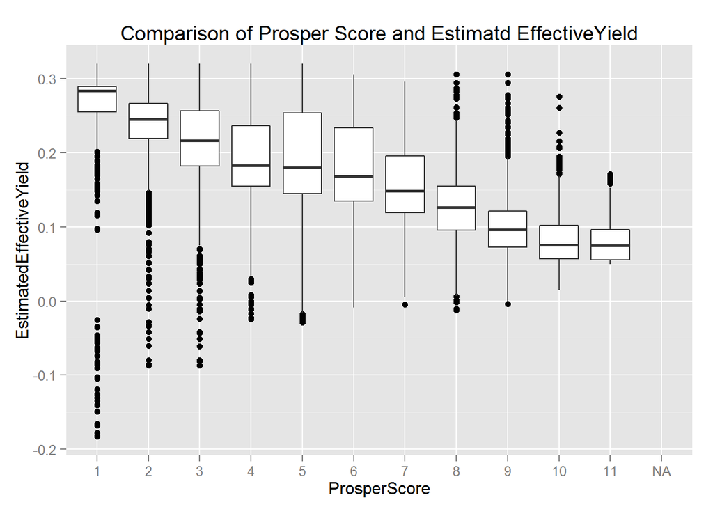

Diagram indicates risk decreases as credit rating raise, but that tends to supress rates

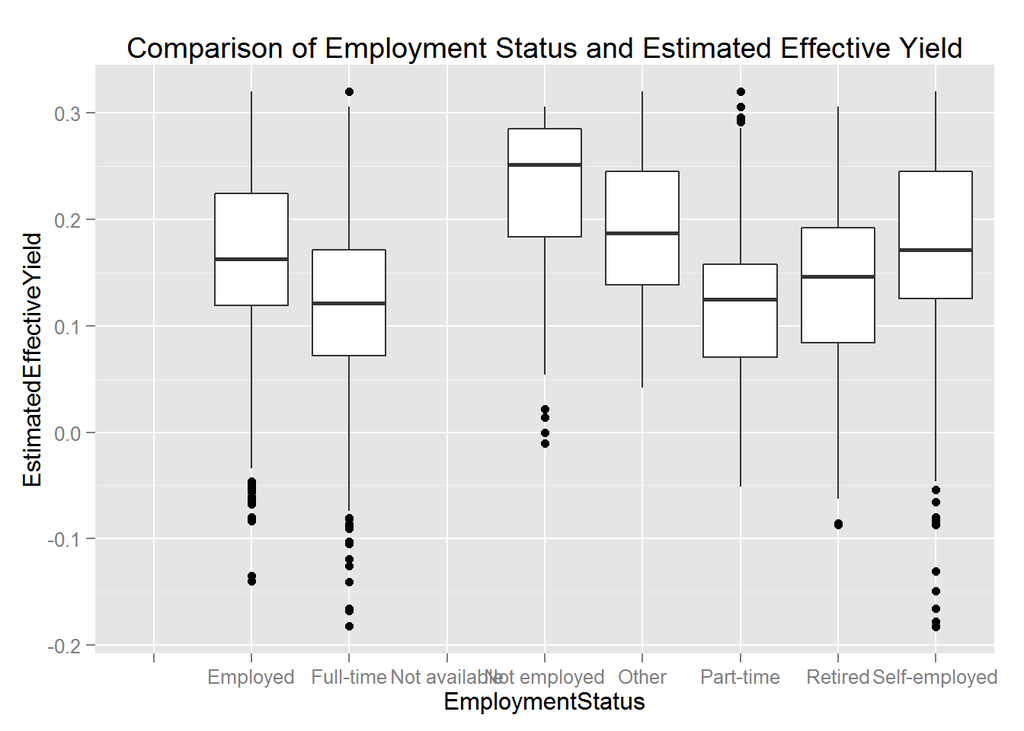